# Experiment 1: Pre-registration code

Sean Trott

January 3, 2021

# Introduction

# Load data

```r
### Set working directory (comment this out to run)
# setwd("/Users/seantrott/Dropbox/UCSD/Research/Ambiguity/SSD/trott_polysemy_experiment/src/analysis")

### Load preprocessed data
df_e1 = read_csv("../../data/processed/polysemy_s1_main.csv")
### Filter to trials from main study (including fillers)
df_e1_main = df_e1 %>%
  filter(practice == "main")
nrow(df_e1_main)
```

```
## [1] 48384
```

```r
### critical trials
df_e1_critical = df_e1 %>%
  filter(critical == "yes") %>%
  filter(order == "second") ## Get only "second" trials (should be 56 per ppt)
nrow(df_e1_critical)
```

```
## [1] 12096
```

```r
### Info about study
length(unique(df_e1_critical$subject))
```

```
## [1] 216
```

```r
table(df_e1_critical$same, df_e1_critical$ambiguity_type)
```

```
##
##         Homonymy Polysemy
##   FALSE     2324     5646
##   TRUE      1182     2944
```

```r
### Recode version information to omit order, so it can be merged with distance information
df_e1_critical$version = fct_recode(
  df_e1_critical$version_with_order,
  M1_a_M1_b = "M1_b_M1_a",
  M1_b_M2_a = "M2_a_M1_b",
  M1_a_M2_a = "M2_a_M1_a",
  M1_a_M2_b = "M2_b_M1_a",
  M1_b_M2_b = "M2_b_M1_b",
  M2_a_M2_b = "M2_b_M2_a"
)
```

# Preprocessing

## Bot checks

```r
df_ppt_bots = df_e1 %>%
  filter(type == "bot_check") %>%
  mutate(b1_correct = B1 == 2,
         b2_correct = B2 == "Chair")

df_bot_summ = df_ppt_bots %>%
  group_by(subject) %>%
  summarise(bot_avg = (b1_correct + b2_correct) / 2)
df_bot_summ
```

```
## # A tibble: 216 x 2
##    subject    bot_avg
##    <chr>        <dbl>
##  1 06za8waveg     1
##  2 0ajdaa03qg     1
##  3 0dejv51fpt     1
##  4 0dzgg6yv9f     1
##  5 0gume44e3x     0.5
##  6 0kzq00hzcv     1
##  7 0tbxffl3va     1
##  8 0tcxalq3x6     1
##  9 0w79pn4dga     1
## 10 15fqjmdyck     1
## # … with 206 more rows
```

```r
## Now remove ppts from critical stims that have < 100% avearge
df_e1_critical = df_e1_critical %>%
  left_join(df_bot_summ, by = "subject") %>%
  filter(bot_avg == 1)
length(unique(df_e1_critical$subject))
```

```
## [1] 213
```

## Demographic data

After preprocessing:

```r
df_demo = df_e1_critical %>%
  group_by(subject, Gender, Native_Speaker, Mobile_Device, Age) %>%
  summarise(mean_rt = mean(rt))
table(df_demo$Gender)
```

```
##
##               Female                 Male           Non-binary
##                  165                   43                    2
## Prefer not to answer
##                    3
```

```r
table(df_demo$Native_Speaker)
```

```
##
##                   No Prefer not to answer                  Yes
##                    8                    2                  203
```

```r
table(df_demo$Mobile_Device)
```

```
##
##  No Yes
## 208   5
```

```r
# For Age calculations only, ignore subject who responded with string
df_demo = df_demo %>%
  filter(Age != "n/a")
df_demo$age = as.numeric(df_demo$Age)

mean(df_demo$age, na.rm = TRUE)
```

```
## [1] 20.42925
```

```r
sd(df_demo$age, na.rm = TRUE)
```

```
## [1] 1.605587
```

```r
range(df_demo$age, na.rm = TRUE)
```

```
## [1] 18 29
```

Exclude non-native speakers:

```r
df_e1_critical = df_e1_critical %>%
  filter(Native_Speaker == "Yes")
length(unique(df_e1_critical$subject))
```

```
## [1] 203
```

Exclude people who performed experiment on mobile device:

```r
df_e1_critical = df_e1_critical %>%
  filter(Mobile_Device == "No")
length(unique(df_e1_critical$subject))
```

```
## [1] 200
```

## Remove RTs

First, we remove trials with an RT < 500ms. For convenience, we also log RT here.

```r
df_e1_critical = df_e1_critical %>%
  filter(rt > 500) %>% ## Remove <= 500 ms
  mutate(log_rt = log(rt)) ## Log RT

nrow(df_e1_critical)
```

```
## [1] 9998
```

Second, we remove trials with an RT > 3 SDs above a subject's mean.

```r
df_e1_critical = df_e1_critical %>%
  group_by(subject) %>%
  mutate(rt_z = scale(rt))

df_e1_critical = df_e1_critical %>%
  filter(rt_z < 3)
nrow(df_e1_critical)
```

```
## [1] 9764
```

## Remove subjects with too few observations

Finally, we remove subjects for whom more than half the observations have been removed (for slow or very fast RTs).

```r
HALF = 28

df_e1_critical = df_e1_critical %>%
  group_by(subject) %>%
  mutate(count = n())

df_e1_critical = df_e1_critical %>%
  filter(count > HALF)
nrow(df_e1_critical)
```

```
## [1] 9682
```

```r
length(unique(df_e1_critical$subject))
```

```
## [1] 180
```

# Merge with NLM distances and norming data

Here, we merge the results from the neural language model (NLM) analyses, as well as our norming data.

## Load NLM and norming data

```r
df_distances = read_csv("../../data/processed/stims_processed.csv")
nrow(df_distances)
```

```
## [1] 690
```

```r
df_distances = df_distances %>%
  select(word, version, same, ambiguity_type,
         distance_bert, distance_elmo)

df_normed = read_csv("../../data/stims/item_means.csv")
nrow(df_normed)
```

```
## [1] 672
```

```r
df_normed = df_normed %>%
  select(word, version, same, ambiguity_type, distance_bert, distance_elmo,
         mean_relatedness, median_relatedness, sd_relatedness, se_relatedness, count)


df_item_data = df_normed %>%
  left_join(df_distances, by = c("word", "version",
                                 "same", "ambiguity_type",
                                 "distance_bert", "distance_elmo")) %>%
  mutate(same = factor(same))
nrow(df_item_data)
```

```
## [1] 672
```

```r
table(df_item_data$ambiguity_type, df_item_data$same)
```

```
##
##            FALSE TRUE
##   Homonymy   152   76
##   Polysemy   296  148
```

## Merge with experimental data

```r
df_merged = df_e1_critical %>%
  mutate(same = factor(same)) %>%
  left_join(df_item_data, by = c("word", "version",  "same", "ambiguity_type")) %>%
  mutate(length = nchar(word))

nrow(df_e1_critical)
```

```
## [1] 9682
```

```r
nrow(df_merged)
```

```
## [1] 9682
```

```r
length(unique(df_merged$subject))
```

```
## [1] 180
```

```r
summary(df_merged$mean_relatedness)
```

```
##    Min. 1st Qu.  Median    Mean 3rd Qu.    Max.
##   0.000   0.700   2.235   2.114   3.500   4.000
```

```r
summary(df_merged$distance_bert)
```

```
##     Min.  1st Qu.   Median     Mean  3rd Qu.     Max.
## 0.009858 0.146083 0.252053 0.266825 0.366402 0.749923
```

```r
# Reorder factor levels
df_merged$ambiguity_type = factor(df_merged$ambiguity_type, levels = c('Polysemy', 'Homonymy'))
df_merged$same = factor(df_merged$same, levels = c(TRUE, FALSE))
```

# Demographic data (pt. 2)

After all exclusions (added this *post* pre-registration, for numbers in mansucript; doesn't change anything about the data, just reports on after excluding):

```r
df_demo = df_merged %>%
  group_by(subject, Gender, Native_Speaker, Mobile_Device, Age) %>%
  summarise(mean_rt = mean(rt))
nrow(df_demo)
```

```
## [1] 180
```

```r
table(df_demo$Gender)
```

```
##
##               Female                 Male           Non-binary
##                  144                   33                    2
## Prefer not to answer
##                    1
```

```r
table(df_demo$Native_Speaker)
```

```
##
## Yes
## 180
```

```r
table(df_demo$Mobile_Device)
```

```
##
##  No
## 180
```

```r
# For Age calculations only, ignore subject who responded with string
df_demo = df_demo %>%
  filter(Age != "n/a")
df_demo$age = as.numeric(df_demo$Age)

mean(df_demo$age, na.rm = TRUE)
```

```
## [1] 20.48889
```

```r
sd(df_demo$age, na.rm = TRUE)
```

```
## [1] 1.672949
```

```r
range(df_demo$age, na.rm = TRUE)
```

```
## [1] 18 29
```

# Descriptive results

## Accuracy

First, let's just look at accuracy overall on all the "main" trials, broken up by `filler` vs. `critical` and `first` vs. `second`. Most participants scored above 50% for both `critical` and `filler` trials (though slightly better on `filler` trials), and achieved similar accuracy for `first` and `second` trials.

```r
df_e1_main %>%
  group_by(critical, order) %>%
  summarise(accuracy = mean(correct_response))
```

```
## # A tibble: 4 x 3
## # Groups:   critical [2]
##   critical order  accuracy
##   <chr>    <chr>     <dbl>
## 1 no       first     0.840
## 2 no       second    0.844
## 3 yes      first     0.801
## 4 yes      second    0.795
```

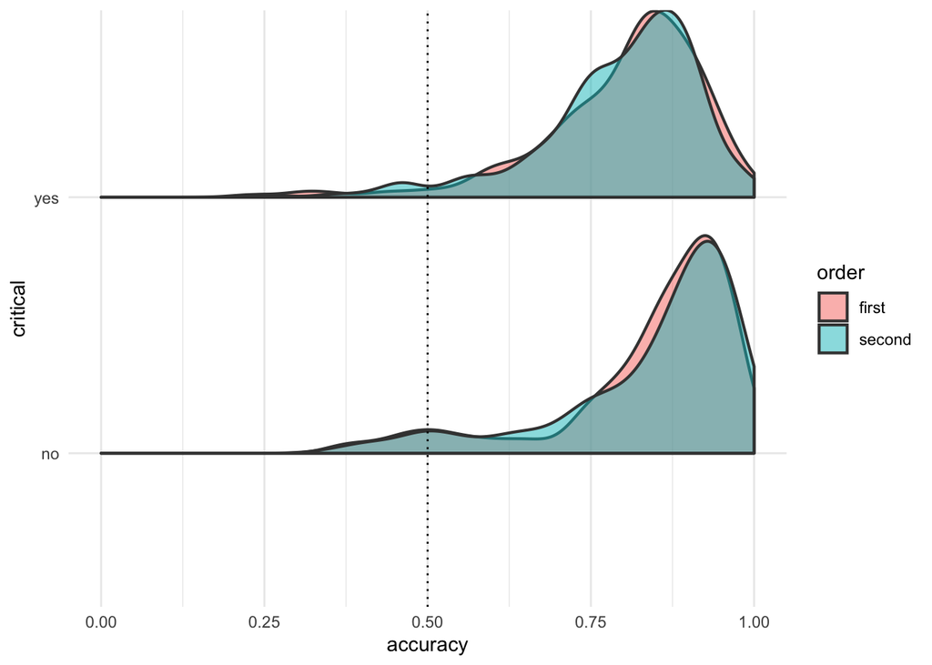

```r
df_e1_main %>%
  group_by(subject, critical, order) %>%
  summarise(accuracy = mean(correct_response)) %>%
  ggplot(aes(x = accuracy,
             y = critical,
             fill = order)) +
  geom_density_ridges2(aes(height = ..density..),
                       color=gray(0.25), alpha = 0.5,
                       scale=0.85, size=0.75, stat="density") +
  geom_vline(xintercept = .5, linetype = "dotted") +
  scale_x_continuous(limits = c(0, 1)) +
  theme_minimal()
```

We can also look at accuracy on the critical trials, broken up by condition. Interestingly, we see that the distribution of accuracy scores on **critical trials** (by participant) is different for `same` vs. `different` sense usages, and lowest still for `different sense` `homonymy`.

```r
df_merged %>%
  group_by(same, ambiguity_type) %>%
  summarise(accuracy = mean(correct_response))
```

```
## # A tibble: 4 x 3
## # Groups:   same [2]
##   same  ambiguity_type accuracy
##   <fct> <fct>             <dbl>
## 1 TRUE  Polysemy          0.922
## 2 TRUE  Homonymy          0.820
## 3 FALSE Polysemy          0.841
## 4 FALSE Homonymy          0.695
```

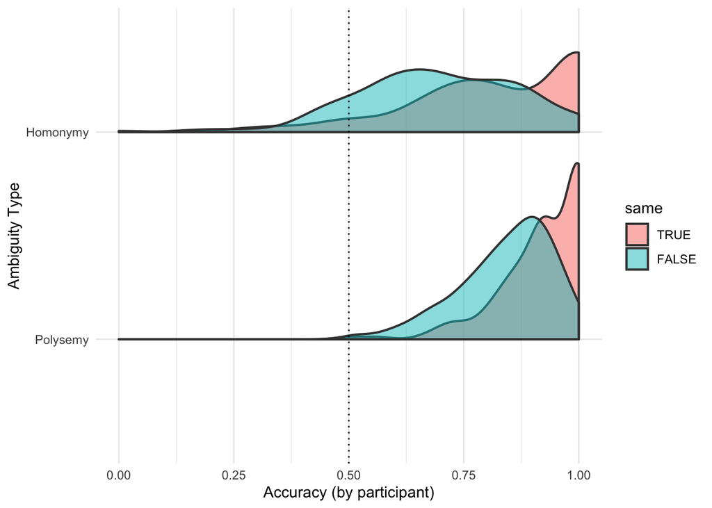

```r
df_merged %>%
  group_by(subject, same, ambiguity_type) %>%
  summarise(accuracy = mean(correct_response)) %>%
  ggplot(aes(x = accuracy,
             y = ambiguity_type,
             fill = same)) +
  geom_density_ridges2(aes(height = ..density..),
                       color=gray(0.25), alpha = 0.5,
                       scale=0.85, size=0.75, stat="density") +
  geom_vline(xintercept = .5, linetype = "dotted") +
  scale_x_continuous(limits = c(0, 1)) +
  labs(x = "Accuracy (by participant)",
       y = "Ambiguity Type",
       color = "Same Sense") +
  theme_minimal()
```

## RT

Now let's look at the `RT` distribution. As expected, RT is right-skewed:

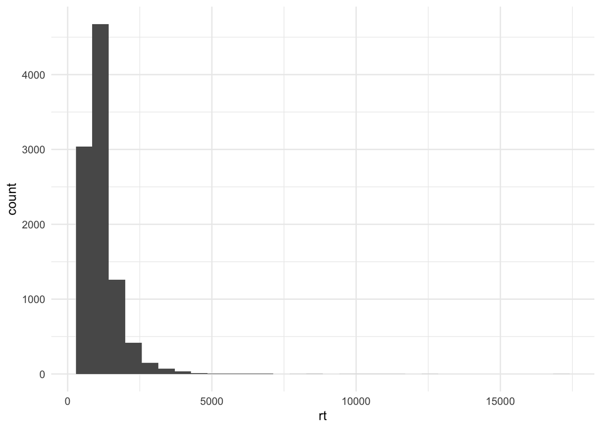

```r
df_merged %>%
  ggplot(aes(x = rt)) +
  geom_histogram() +
  theme_minimal()
```

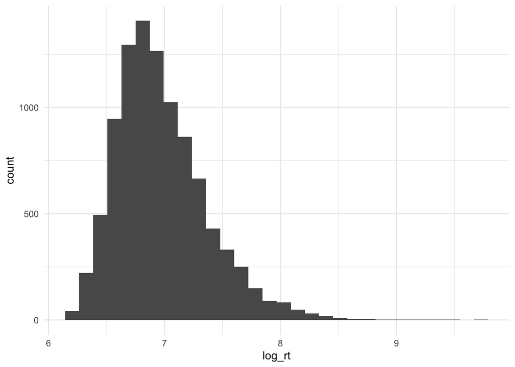

```r
df_merged %>%
  ggplot(aes(x = log_rt)) +
  geom_histogram() +
  theme_minimal()
```

```r
df_merged %>%
  group_by(same) %>%
  summarise(mean_rt = mean(rt),
            mean_log_rt = mean(log_rt))
```

```
## # A tibble: 2 x 3
##   same  mean_rt mean_log_rt
##   <fct>   <dbl>       <dbl>
## 1 TRUE    1118.        6.93
## 2 FALSE   1197.        7.00
```

# Analyses

## Build all models

### Accuracy

```r
model_full_acc = glmer(data = df_merged,
                  correct_response ~ distance_bert + ambiguity_type * same +
                    Conc.M + log_freq + Class + length +
                    (1 + distance_bert + ambiguity_type + same | subject) +
                    (1 | word),
                  control=glmerControl(optimizer="bobyqa"),
                  family = binomial())
model_interaction_no_distance_acc = glmer(data = df_merged,
                  correct_response ~ ambiguity_type * same +
                    Conc.M + log_freq + Class + length +
                    (1 + distance_bert + ambiguity_type + same | subject) +
                    (1 | word),
                  control=glmerControl(optimizer="bobyqa"),
                  family = binomial())
model_all_main_effects_acc = glmer(data = df_merged,
                  correct_response ~ distance_bert + ambiguity_type + same +
                    Conc.M + log_freq + Class + length +
                    (1 + distance_bert + ambiguity_type + same | subject) +
                    (1 | word),
                  control=glmerControl(optimizer="bobyqa"),
                  family = binomial())
model_distance_same_acc = glmer(data = df_merged,
                  correct_response ~ distance_bert + same +
                    Conc.M + log_freq + Class + length +
                    (1 + distance_bert + same + ambiguity_type | subject) +
                    (1 | word),
                  control=glmerControl(optimizer="bobyqa"),
                  family = binomial())
```

```
## boundary (singular) fit: see ?isSingular
```

```r
model_distance_acc = glmer(data = df_merged,
                  correct_response ~ distance_bert +
                    Conc.M + log_freq + Class + length +
                    (1 + distance_bert + same + ambiguity_type | subject) +
                    (1 | word),
                  control=glmerControl(optimizer="bobyqa"),
                  family = binomial())
```

### RT

```r
df_merged_correct = df_merged %>%
  filter(correct_response == TRUE)

model_full_rt = lmer(data = df_merged_correct,
                  log_rt ~ distance_bert + ambiguity_type * same +
                    Conc.M + log_freq + Class + length +
                    (1 + distance_bert + ambiguity_type + same | subject) +
                    (1 | word),
                  control=lmerControl(optimizer="bobyqa"),
                  REML = FALSE)
```

```
## boundary (singular) fit: see ?isSingular
```

```r
model_interaction_no_distance_rt = lmer(data = df_merged_correct,
                  log_rt ~ ambiguity_type * same +
                    Conc.M + log_freq + Class + length +
                    (1 + distance_bert + ambiguity_type + same | subject) +
                    (1 | word),
                  control=lmerControl(optimizer="bobyqa"),
                  REML = FALSE)
```

```
## boundary (singular) fit: see ?isSingular
```

```r
model_all_main_effects_rt = lmer(data = df_merged_correct,
                  log_rt ~ distance_bert + ambiguity_type + same +
                    Conc.M + log_freq + Class + length +
                    (1 + distance_bert + ambiguity_type + same | subject) +
                    (1 | word),
                  control=lmerControl(optimizer="bobyqa"),
                  REML = FALSE)
```

```
## boundary (singular) fit: see ?isSingular
```

```r
model_distance_same_rt = lmer(data = df_merged_correct,
                  log_rt ~ distance_bert + same +
                    Conc.M + log_freq + Class + length +
                    (1 + distance_bert + same + ambiguity_type | subject) +
                    (1 | word),
                  control=lmerControl(optimizer="bobyqa"),
                  REML = FALSE)
```

```
## boundary (singular) fit: see ?isSingular
```

```r
model_distance_rt = lmer(data = df_merged_correct,
                  log_rt ~ distance_bert +
                    Conc.M + log_freq + Class + length +
                    (1 + distance_bert + same + ambiguity_type | subject) +
                    (1 | word),
                  control=lmerControl(optimizer="bobyqa"),
                  REML = FALSE)
```

## Visualizations

### Accuracy

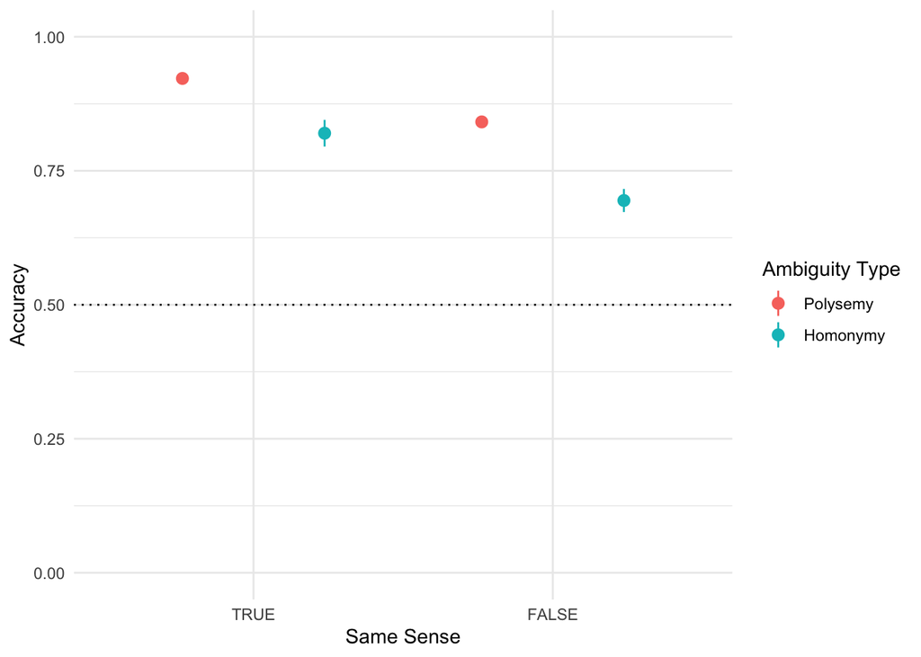

```r
df_merged %>%
  mutate(correct_numeric = as.numeric(correct_response)) %>%
  ggplot(aes(x = same,
             y = correct_numeric,
             color = ambiguity_type)) +
  stat_summary (fun = function(x){mean(x)},
                fun.min = function(x){mean(x) - 2*sd(x)/sqrt(length(x))},
                fun.max = function(x){mean(x) + 2*sd(x)/sqrt(length(x))},
                geom= 'pointrange',
                position=position_dodge(width=0.95)) +
  geom_hline(yintercept = .5, linetype = "dotted") +
  labs(x = "Same Sense",
       y = "Accuracy",
       color = "Ambiguity Type") +
  scale_y_continuous(limits = c(0, 1)) +
  theme_minimal()
```

### RT

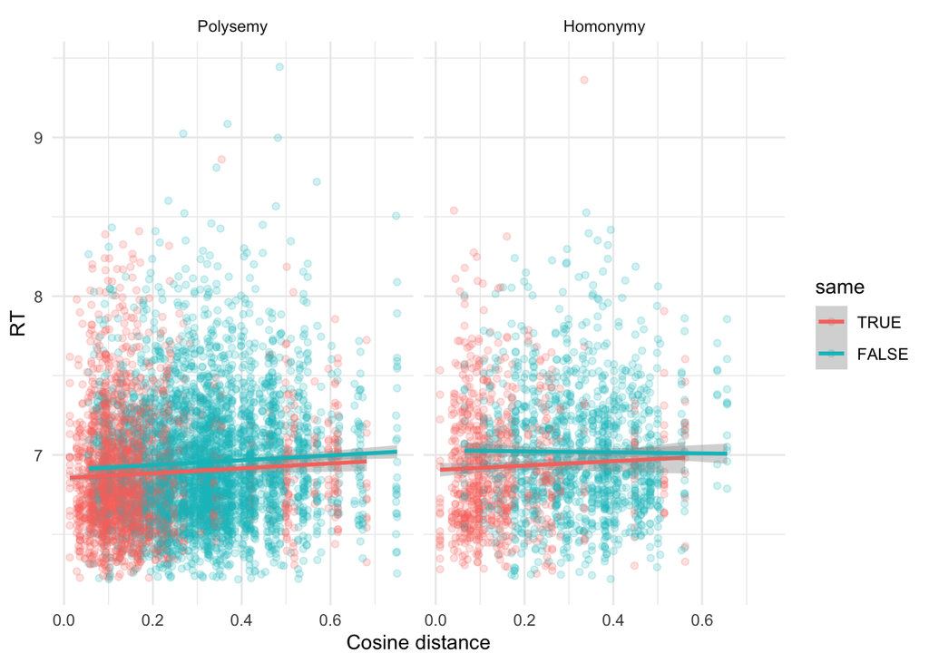

```r
df_merged_correct %>%
  ggplot(aes(x = distance_bert,
             y = log_rt,
             color = same)) +
  geom_point(alpha = .2) +
  geom_smooth(method = "lm") +
  theme_minimal() +
  labs(x = "Cosine distance",
       y = "RT") +
  facet_grid(~ambiguity_type)
```

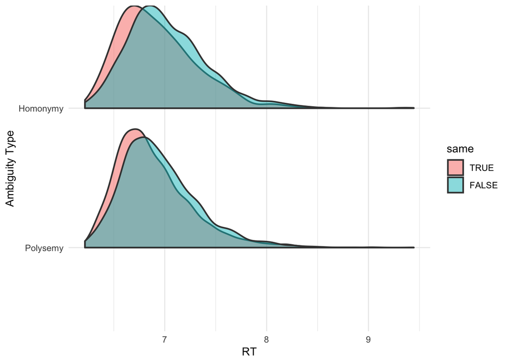

```r
df_merged_correct %>%
  ggplot(aes(x = log_rt,
             y = ambiguity_type,
             fill = same)) +
  geom_density_ridges2(aes(height = ..density..),
                       color=gray(0.25), alpha = 0.5,
                       scale=0.85, size=0.75, stat="density") +
  labs(x = "RT",
       y = "Ambiguity Type",
       color = "Same Sense") +
  theme_minimal()
```

## Disconfirmatory analyses: Accuracy

### Model summaries

```r
summary(model_full_acc)
```

```
## Generalized linear mixed model fit by maximum likelihood (Laplace
##   Approximation) [glmerMod]
##  Family: binomial  ( logit )
## Formula: correct_response ~ distance_bert + ambiguity_type * same + Conc.M +
##     log_freq + Class + length + (1 + distance_bert + ambiguity_type +
##     same | subject) + (1 | word)
##    Data: df_merged
## Control: glmerControl(optimizer = "bobyqa")
##
##      AIC      BIC   logLik deviance df.resid
##   7888.3   8031.8  -3924.1   7848.3     9662
##
## Scaled residuals:
##     Min      1Q  Median      3Q     Max
## -6.9992  0.1771  0.3081  0.4596  1.4947
##
## Random effects:
##  Groups  Name                   Variance Std.Dev. Corr
##  subject (Intercept)            0.518856 0.72032
##          distance_bert          0.007635 0.08738   0.98
##          ambiguity_typeHomonymy 0.126239 0.35530  -0.92 -0.86
##          sameFALSE              0.115215 0.33943  -0.60 -0.65  0.73
##  word    (Intercept)            0.579371 0.76116
## Number of obs: 9682, groups:  subject, 180; word, 104
##
## Fixed effects:
##                                  Estimate Std. Error z value Pr(>|z|)
## (Intercept)                       2.83991    0.84652   3.355 0.000794 ***
## distance_bert                    -0.17643    0.34289  -0.515 0.606864
## ambiguity_typeHomonymy           -1.13685    0.24433  -4.653 3.27e-06 ***
## sameFALSE                        -0.98323    0.11799  -8.333  < 2e-16 ***
## Conc.M                           -0.14209    0.11713  -1.213 0.225086
## log_freq                          0.28165    0.14710   1.915 0.055531 .
## ClassV                           -0.32111    0.19704  -1.630 0.103172
## length                           -0.02340    0.05358  -0.437 0.662304
## ambiguity_typeHomonymy:sameFALSE  0.25346    0.14538   1.743 0.081259 .
## ---
## Signif. codes:  0 '***' 0.001 '**' 0.01 '*' 0.05 '.' 0.1 ' ' 1
##
## Correlation of Fixed Effects:
##             (Intr) dstnc_ ambg_H sFALSE Conc.M lg_frq ClassV length
## distanc_brt -0.068
## ambgty_typH -0.276 -0.010
## sameFALSE   -0.062 -0.437  0.298
## Conc.M      -0.616  0.064 -0.225 -0.025
## log_freq    -0.666 -0.045  0.332  0.008 -0.022
## ClassV      -0.281  0.039  0.134 -0.009  0.098  0.059
## length      -0.667 -0.030  0.316  0.016  0.230  0.295  0.355
## amb_H:FALSE  0.069 -0.063 -0.456 -0.551 -0.009  0.011 -0.010  0.000
## convergence code: 1
```

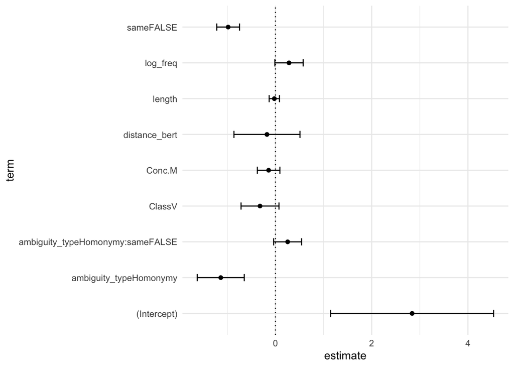

```r
df_tidy_acc = broom.mixed::tidy(model_full_acc)

df_tidy_acc %>%
  filter(effect == "fixed") %>%
  ggplot(aes(x = term,
             y = estimate)) +
  geom_point() +
  coord_flip() +
  geom_hline(yintercept = 0, linetype = "dotted") +
  geom_errorbar(aes(ymin = estimate - 2*std.error,
                    ymax = estimate + 2*std.error),
                width=.2,
                position=position_dodge(.9)) +
  theme_minimal()
```

### Disconfirm Account 1

```r
dis1_acc = anova(model_distance_same_acc, model_distance_acc)
dis1_acc
```

```
## Data: df_merged
## Models:
## model_distance_acc: correct_response ~ distance_bert + Conc.M + log_freq + Class +
## model_distance_acc:     length + (1 + distance_bert + same + ambiguity_type | subject) +
## model_distance_acc:     (1 | word)
## model_distance_same_acc: correct_response ~ distance_bert + same + Conc.M + log_freq +
## model_distance_same_acc:     Class + length + (1 + distance_bert + same + ambiguity_type |
## model_distance_same_acc:     subject) + (1 | word)
##                         npar    AIC    BIC  logLik deviance  Chisq Df
## model_distance_acc        17 7979.8 8101.8 -3972.9   7945.8
## model_distance_same_acc   18 7904.6 8033.8 -3934.3   7868.6 77.171  1
##                         Pr(>Chisq)
## model_distance_acc
## model_distance_same_acc  < 2.2e-16 ***
## ---
## Signif. codes:  0 '***' 0.001 '**' 0.01 '*' 0.05 '.' 0.1 ' ' 1
```

### Disconfirm Account 2 (and 4)

```r
dis24_acc = anova(model_full_acc, model_interaction_no_distance_acc)
dis24_acc
```

```
## Data: df_merged
## Models:
## model_interaction_no_distance_acc: correct_response ~ ambiguity_type * same + Conc.M + log_freq +
## model_interaction_no_distance_acc:     Class + length + (1 + distance_bert + ambiguity_type + same |
## model_interaction_no_distance_acc:     subject) + (1 | word)
## model_full_acc: correct_response ~ distance_bert + ambiguity_type * same + Conc.M +
## model_full_acc:     log_freq + Class + length + (1 + distance_bert + ambiguity_type +
## model_full_acc:     same | subject) + (1 | word)
##                                   npar    AIC    BIC  logLik deviance  Chisq Df
## model_interaction_no_distance_acc   19 7886.5 8022.9 -3924.3   7848.5
## model_full_acc                      20 7888.3 8031.8 -3924.1   7848.3 0.2529  1
##                                   Pr(>Chisq)
## model_interaction_no_distance_acc
## model_full_acc                         0.615
```

### Disconfirm Account 1-3

```r
dis13_acc = anova(model_full_acc, model_all_main_effects_acc)
dis13_acc
```

```
## Data: df_merged
## Models:
## model_all_main_effects_acc: correct_response ~ distance_bert + ambiguity_type + same + Conc.M +
## model_all_main_effects_acc:     log_freq + Class + length + (1 + distance_bert + ambiguity_type +
## model_all_main_effects_acc:     same | subject) + (1 | word)
## model_full_acc: correct_response ~ distance_bert + ambiguity_type * same + Conc.M +
## model_full_acc:     log_freq + Class + length + (1 + distance_bert + ambiguity_type +
## model_full_acc:     same | subject) + (1 | word)
##                            npar    AIC    BIC  logLik deviance  Chisq Df
## model_all_main_effects_acc   19 7889.2 8025.6 -3925.6   7851.2
## model_full_acc               20 7888.3 8031.8 -3924.1   7848.3 2.9815  1
##                            Pr(>Chisq)
## model_all_main_effects_acc
## model_full_acc                0.08422 .
## ---
## Signif. codes:  0 '***' 0.001 '**' 0.01 '*' 0.05 '.' 0.1 ' ' 1
```

## Disconfirmatory analyses: RT

### Model summaries

```r
summary(model_full_rt)
```

```
## Linear mixed model fit by maximum likelihood  ['lmerMod']
## Formula: log_rt ~ distance_bert + ambiguity_type * same + Conc.M + log_freq +
##     Class + length + (1 + distance_bert + ambiguity_type + same |
##     subject) + (1 | word)
##    Data: df_merged_correct
## Control: lmerControl(optimizer = "bobyqa")
##
##      AIC      BIC   logLik deviance df.resid
##   5261.2   5408.0  -2609.6   5219.2     8026
##
## Scaled residuals:
##     Min      1Q  Median      3Q     Max
## -3.3516 -0.6620 -0.1445  0.5140  7.0577
##
## Random effects:
##  Groups   Name                   Variance Std.Dev. Corr
##  subject  (Intercept)            0.036539 0.19115
##           distance_bert          0.009193 0.09588   0.28
##           ambiguity_typeHomonymy 0.002175 0.04663  -0.37 -0.48
##           sameFALSE              0.003291 0.05737  -0.34 -0.36  0.99
##  word     (Intercept)            0.004524 0.06726
##  Residual                        0.102296 0.31984
## Number of obs: 8047, groups:  subject, 180; word, 104
##
## Fixed effects:
##                                   Estimate Std. Error t value
## (Intercept)                       6.875411   0.079574  86.403
## distance_bert                     0.144910   0.036675   3.951
## ambiguity_typeHomonymy            0.039987   0.023224   1.722
## sameFALSE                         0.063191   0.011073   5.707
## Conc.M                            0.008201   0.010645   0.770
## log_freq                         -0.024605   0.013785  -1.785
## ClassV                           -0.050927   0.018311  -2.781
## length                            0.008055   0.004910   1.640
## ambiguity_typeHomonymy:sameFALSE  0.009808   0.017327   0.566
##
## Correlation of Fixed Effects:
##             (Intr) dstnc_ ambg_H sFALSE Conc.M lg_frq ClassV length
## distanc_brt -0.058
## ambgty_typH -0.261 -0.014
## sameFALSE   -0.041 -0.491  0.247
## Conc.M      -0.601  0.055 -0.223 -0.028
## log_freq    -0.683 -0.047  0.334  0.013 -0.001
## ClassV      -0.262  0.045  0.129 -0.021  0.095  0.045
## length      -0.656 -0.038  0.310  0.021  0.218  0.316  0.348
## amb_H:FALSE  0.035 -0.068 -0.458 -0.368 -0.006  0.013 -0.012  0.005
## convergence code: 0
## boundary (singular) fit: see ?isSingular
```

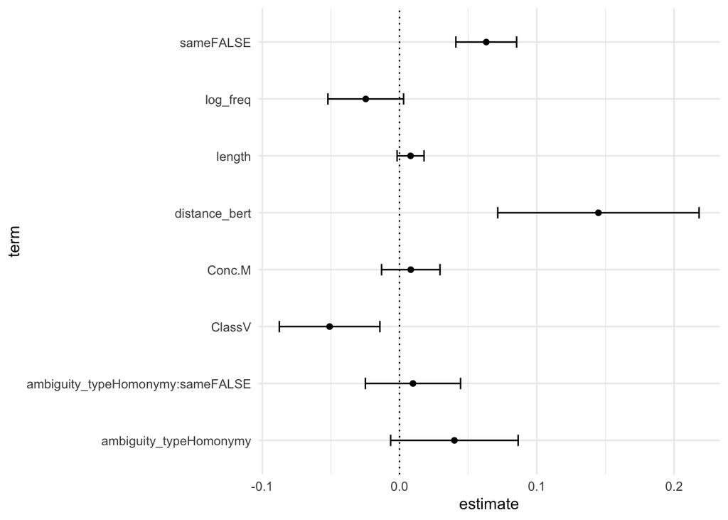

```r
df_tidy_rt = broom.mixed::tidy(model_full_rt)

df_tidy_rt %>%
  filter(effect == "fixed") %>%
  filter(term != "(Intercept)") %>%
  ggplot(aes(x = term,
             y = estimate)) +
  geom_point() +
  coord_flip() +
  geom_hline(yintercept = 0, linetype = "dotted") +
  geom_errorbar(aes(ymin = estimate - 2*std.error,
                    ymax = estimate + 2*std.error),
                width=.2,
                position=position_dodge(.9)) +
  theme_minimal()
```

### Disconfirm Account 1

```r
dis1_rt = anova(model_distance_same_rt, model_distance_rt)
dis1_rt
```

```
## Data: df_merged_correct
## Models:
## model_distance_rt: log_rt ~ distance_bert + Conc.M + log_freq + Class + length +
## model_distance_rt:     (1 + distance_bert + same + ambiguity_type | subject) + (1 |
## model_distance_rt:     word)
## model_distance_same_rt: log_rt ~ distance_bert + same + Conc.M + log_freq + Class + length +
## model_distance_same_rt:     (1 + distance_bert + same + ambiguity_type | subject) + (1 |
## model_distance_same_rt:     word)
##                        npar    AIC    BIC  logLik deviance  Chisq Df Pr(>Chisq)
## model_distance_rt        18 5294.8 5420.6 -2629.4   5258.8
## model_distance_same_rt   19 5262.3 5395.2 -2612.2   5224.3 34.425  1   4.43e-09
##
## model_distance_rt
## model_distance_same_rt ***
## ---
## Signif. codes:  0 '***' 0.001 '**' 0.01 '*' 0.05 '.' 0.1 ' ' 1
```

### Disconfirm Account 2 (and 4)

```r
dis24_rt = anova(model_full_rt, model_interaction_no_distance_rt)
dis24_rt
```

```
## Data: df_merged_correct
## Models:
## model_interaction_no_distance_rt: log_rt ~ ambiguity_type * same + Conc.M + log_freq + Class +
## model_interaction_no_distance_rt:     length + (1 + distance_bert + ambiguity_type + same | subject) +
## model_interaction_no_distance_rt:     (1 | word)
## model_full_rt: log_rt ~ distance_bert + ambiguity_type * same + Conc.M + log_freq +
## model_full_rt:     Class + length + (1 + distance_bert + ambiguity_type + same |
## model_full_rt:     subject) + (1 | word)
##                                  npar    AIC    BIC  logLik deviance  Chisq Df
## model_interaction_no_distance_rt   20 5274.6 5414.4 -2617.3   5234.6
## model_full_rt                      21 5261.2 5408.0 -2609.6   5219.2 15.419  1
##                                  Pr(>Chisq)
## model_interaction_no_distance_rt
## model_full_rt                     8.612e-05 ***
## ---
## Signif. codes:  0 '***' 0.001 '**' 0.01 '*' 0.05 '.' 0.1 ' ' 1
```

### Disconfirm Account 1-3

```r
dis13_rt = anova(model_full_rt, model_all_main_effects_rt)
dis13_rt
```

```
## Data: df_merged_correct
## Models:
## model_all_main_effects_rt: log_rt ~ distance_bert + ambiguity_type + same + Conc.M + log_freq +
## model_all_main_effects_rt:     Class + length + (1 + distance_bert + ambiguity_type + same |
## model_all_main_effects_rt:     subject) + (1 | word)
## model_full_rt: log_rt ~ distance_bert + ambiguity_type * same + Conc.M + log_freq +
## model_full_rt:     Class + length + (1 + distance_bert + ambiguity_type + same |
## model_full_rt:     subject) + (1 | word)
##                           npar    AIC    BIC  logLik deviance  Chisq Df
## model_all_main_effects_rt   20 5259.5 5399.4 -2609.7   5219.5
## model_full_rt               21 5261.2 5408.0 -2609.6   5219.2 0.3202  1
##                           Pr(>Chisq)
## model_all_main_effects_rt
## model_full_rt                 0.5715
```

## Correct for multiple comparisons

Finally, for each pair of tests (e.g., disconfirming account 1) across the two dependent measures, we adjust for multiple comparisons (as two DVs were considered).

Account 1:

```r
p.adjust(c(dis1_acc$`Pr(>Chisq)`[2], dis1_rt$`Pr(>Chisq)`[2]), method = "holm")
```

```
## [1] 3.134732e-18 4.430401e-09
```

Accounts 2 and 4:

```r
p.adjust(c(dis24_acc$`Pr(>Chisq)`[2], dis24_rt$`Pr(>Chisq)`[2]), method = "holm")
```

```
## [1] 0.6150077763 0.0001722475
```

Accounts 1-3:

```r
p.adjust(c(dis13_acc$`Pr(>Chisq)`[2], dis13_rt$`Pr(>Chisq)`[2]), method = "holm")
```

```
## [1] 0.1684380 0.5715007
```